# Replication of Austerweil & Griffiths (2011)

Natalia Vélez

March 8, 2015

### Data preparation

**Step 1:** Loading data

```r
# Helpful libraries
library(ggplot2)
library(jsonlite)
library(stringr)
library(tidyr)
library(dplyr)

# Directory containing production results
setwd('~/Documents/Stanford/Classes/W15/Psych 254/psych254_materials/mturk/production-results')

# Get list of files
flist <- list.files(pattern = "*.json")
```

Each JSON file in the production-results folder contains:

- Information about the HIT supplied by mTurk (workerID, approval time, status, assignment ID, etc.)
- A field generated by the experiment script, `answers`, containing:
  - Condition assignment
  - Time completion
  - System information (OS, browser, etc)
  - Information from an optional demographic survey at the end

**Step 2:** Converting JSON files

- `train.data`: Data from training trials
- `test.data`: Data from test trials
- `subj.data`: Demographic, system, and mTurk-specific information for each participant

It is especially important that data from test trials be kept separate from training and subject information, as participants’ responses need to be coded blindly. Subject information is also kept separate from training data to allow the data to be shared. (Testing data is stripped of identifying information, like worker ID, and given a subject-specific placeholder ID in its stead.)

```r
for (i in 1:length(flist)) {
  # Read JSON file as list
  f <- fromJSON(flist[i])

  # Extract subject, training, and test data
  # A placeholder ID is added at the beginning of the data frame
  s <- with(f, data.frame(cbind(i,
                                WorkerId,
                                AssignmentStatus,
                                ApprovalTime,
                                answers$condition,
                                answers$time_in_minutes,
                                answers$subject_information$gender,
                                answers$subject_information$age,
                                answers$subject_information$asses,
                                answers$subject_information$language,
                                answers$subject_information$education,
                                answers$subject_information$enjoyment,
                                answers$subject_information$comments,
                                answers$system$OS,
                                answers$system$Browser)))
  t1 <- cbind(anon = i,
              f$answers$trials[1:50,1:7])
  t2 <- cbind(anon = i,
              f$answers$trials[51:71, 8:11])

  # Add to data frames
  if (exists("subj.data") & exists("train.data") & exists("test.data")) {
    subj.data <- rbind(subj.data, s)
    train.data <- rbind(train.data, t1)
    test.data <- rbind(test.data, t2)
  }
  else {
    subj.data <- s
    train.data <- t1
    test.data <- t2
  }
}

# Rename columns
colnames(subj.data) <- c("anon", "workerid",
                         "status",
                         "approval_time",
                         "condition",
                         "duration",
                         "gender",
                         "age",
                         "understood_hit",
                         "language",
                         "education",
                         "enjoyment",
                         "comments",
                         "os",
                         "browser")
```

**Step 3:** Save data to CSV

After aggregating and cleaning up the data, they are stored in csv files. The purpose of this step is twofold: first, to share replication data that has been stripped of identifying information and, secondly, to code the results from the test phase.

```r
### Run only to generate new files ###
setwd('~/Documents/Stanford/Classes/W15/Psych 254/psych254_materials/data')
write.csv(subj.data, "replication_subjinfo.csv", row.names = F)
write.csv(train.data, "replication_train.csv", row.names = F)
write.csv(test.data, "replication_test_uncoded.csv", row.names = F)
```

### Target of replication

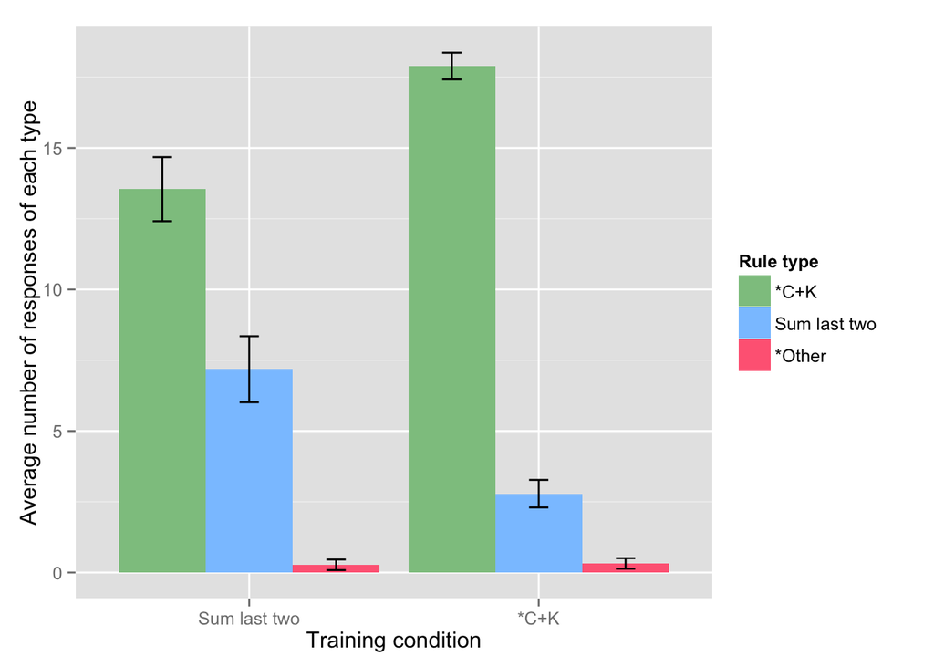

```r
# Load coded data
setwd('~/Documents/Stanford/Classes/W15/Psych 254/psych254_materials/data')
d <- read.csv("replication_test.csv")
subj.data <- read.csv("replication_subjinfo.csv")

# Helper function
sem <- function(x) {sd(x) / sqrt(length(x))}

# Retrieve conditions
d$condition <- subj.data[match(d$anon, subj.data$anon), "condition"]

# Summarize data
d.summ <- d %>%
  group_by(anon) %>%
  summarise(condition = unique(condition),
            xkc_count = sum(ruletype == "xkc"),
            sumtwo_count = sum(ruletype == "sumtwo"),
            other_count = sum(ruletype == "other")) %>%
  group_by(condition) %>%
  summarise(xkc_mean = mean(xkc_count),
            xkc_se = sem(xkc_count),
            sumtwo_mean = mean(sumtwo_count),
            sumtwo_se = sem(sumtwo_count),
            other_mean = mean(other_count),
            other_se = sem(other_count)) %>%
  gather(key, value, -condition) %>%
  extract(key, c("ruletype","stat"), "([a-z]+)_([a-z]+)") %>%
  spread(stat, value)

d.summ$ruletype <- factor(d.summ$ruletype, levels = c("xkc", "sumtwo", "other"))

# Plot data
ggplot(d.summ, aes(x = condition, y = mean, fill = ruletype)) +
  geom_bar(position = "dodge", stat = "identity") +
  geom_errorbar(aes(ymin = mean-se, ymax = mean+se), width = 0.2,
                position = position_dodge(width = .9)) +
  scale_fill_manual(name = "Rule type",
                    breaks = c("xkc", "sumtwo", "other"),
                    labels = c("*C+K", "Sum last two", "*Other"),
                    values = c("#8ec58f","#8ac5ff","#ff6984")) +
  xlab("Training condition") +
  ylab("Average number of responses of each type") +
  scale_x_discrete(breaks = c("sumtwo", "xkc"), labels = c("Sum last two", "*C+K"))
```

```r
# Chi-square test
d.chi <- as.table(matrix(as.numeric(unlist(d.summ[d.summ$ruletype == "sumtwo" | d.summ$ruletype == "xkc", "mean"])), nrow = 2))
d.chi <- rbind(d.chi[1:2], d.chi[3:4])
```

### Additional analyses

**Demographic information:** How many people participated in the HIT? How many were assigned to each condition?

**General task-specific information:** How accurate were participants during the testing phase? Was there a difference in response time between the two types of sequences? Did participants’ speed or accuracy change over the course of the experiment?